# resnet18-compair

**Import libraries**

```python
import time
import torch
import torch.nn as nn
import torch.optim as optim
import torch.nn.functional as F
from torch.utils.data import DataLoader, Dataset, TensorDataset
from torchvision import transforms, models
import numpy as np
import cv2
import os
from sklearn.model_selection import train_test_split
import matplotlib.pyplot as plt
from sklearn.metrics import confusion_matrix
import seaborn as sns
from PIL import Image
from torchvision.transforms import RandomCrop, ColorJitter
from torchvision.models.resnet import ResNet18_Weights
from torchsummary import summary
start_time = time.time()
FINISH = 'FINISH'
```

**Define data directory, emotions and model parameters**

- **data_dir**: data directory where the dataset is stored
- **emotions**: list of emotions that the model will attempt to recognize
- **batch_size**: batch size is a hyperparameter that determines the number of training samples to be processed simultaneously during one iteration of the training process
- **num_epochs**: number of epochs is the number of times the model goes through the entire dataset during the training process
- **learning_rate**: learning rate is a hyperparameter that controls how much the model's weights are updated during each training iteration

```python
data_dir = 'data/AffectNet'
emotions = ['anger', 'contempt', 'disgust', 'fear', 'happy', 'neutral', 'sad', 'surprise']
batch_size = 32
num_epochs = 20
learning_rate = 0.001
FINISH
```

```
'FINISH'
```

**Load filepaths and labels**

- **filepaths**: an empty list that will store the filepaths of all the images in the dataset
- **labels**: an empty list that will store the corresponding emotion labels for each image
- **for label, emotion in enumerate(emotions)**: a loop that iterates over each emotion in the 'emotions' list, while also keeping track of the index (label) of the current emotion
  - **emotion_dir**: a variable that stores the path to the current emotion's directory
  - **for filename in os.listdir(emotion_dir)**: a nested loop that iterates over all files in the current emotion's directory
    - **filepaths.append(os.path.join(emotion_dir, filename))**: appends the complete filepath of the current image file to the 'filepaths' list
    - **labels.append(label)**: appends the corresponding emotion label (index) to the 'labels' list

```python
filepaths = []
labels = []

for label, emotion in enumerate(emotions):
    emotion_dir = os.path.join(data_dir, emotion)
    for filename in os.listdir(emotion_dir):
        filepaths.append(os.path.join(emotion_dir, filename))
        labels.append(label)
FINISH
```

```
'FINISH'
```

**Split data into training, validation, and test sets**

- **X_temp, X_test, y_temp, y_test = train_test_split(filepaths, labels, test_size=0.15, stratify=labels, random_state=42)**: this line of code splits the dataset into a temporary training set (X_temp and y_temp) and a testing set (X_test and y_test) using the `train_test_split()` function from the scikit-learn library. The function takes the following parameters:
  - **filepaths**: the list of filepaths of the images
  - **labels**: the list of emotion labels corresponding to the images
  - **test_size=0.15**: the proportion (15%) of the dataset to be included in the test set
  - **stratify=labels**: ensures that the test set has the same class distribution as the original dataset
  - **random_state=42**: sets the random seed for reproducibility
- **X_train, X_val, y_train, y_val = train_test_split(X_temp, y_temp, test_size=0.176, stratify=y_temp, random_state=42)**: this line of code further splits the temporary training set (X_temp and y_temp) into a final training set (X_train and y_train) and a validation set (X_val and y_val) using the `train_test_split()` function again. The function takes the following parameters:
  - **X_temp**: the list of filepaths of the images in the temporary training set
  - **y_temp**: the list of emotion labels corresponding to the images in the temporary training set
  - **test_size=0.176**: the proportion (17.6%) of the temporary training set to be included in the validation set
  - **stratify=y_temp**: ensures that the validation set has the same class distribution as the temporary training set
  - **random_state=42**: sets the random seed for reproducibility

```python
X_temp, X_test, y_temp, y_test = train_test_split(
    filepaths, labels, test_size=0.15, stratify=labels, random_state=42)
X_train, X_val, y_train, y_val = train_test_split(
    X_temp, y_temp, test_size=0.176, stratify=y_temp, random_state=42)
FINISH
```

```
'FINISH'
```

**Define the preprocess_image function**

- **def preprocess_image(filepath, target_size=(64, 64))**: this function definition takes two arguments, the filepath of the image to be preprocessed, and an optional target_size tuple specifying the desired dimensions of the resized image (default is 64x64).
  - **if not filepath.lower().endswith(('.png', '.jpg', '.jpeg', '.tiff', '.bmp', '.gif'))**: this conditional statement checks if the filepath extension is not one of the accepted image file formats. If the file is not an image, the function prints a warning message and returns `None`.
  - **img = cv2.imread(filepath, cv2.IMREAD_GRAYSCALE)**: this line reads the image file from the given filepath and converts it to grayscale using the OpenCV library.
  - **if img is None**: this conditional statement checks if the image was read successfully. If not, the function prints an error message and returns `None`.
  - **img = cv2.resize(img, target_size)**: this line resizes the image to the specified target_size using the OpenCV library.
  - **img = Image.fromarray(img)**: this line converts the OpenCV image (NumPy array) to a PIL Image object.
  - **return img**: this line returns the preprocessed PIL Image object.

```python
def preprocess_image(filepath, target_size=(64, 64)):
    if not filepath.lower().endswith(('.png', '.jpg', '.jpeg', '.tiff', '.bmp', '.gif')):
        print(f'Skipping non-image file: {filepath}')
        return None

    img = cv2.imread(filepath, cv2.IMREAD_GRAYSCALE)

    if img is None:
        print(f'Error reading file: {filepath}')
        return None

    img = cv2.resize(img, target_size)
    img = Image.fromarray(img)
    return img
FINISH
```

```
'FINISH'
```

**Preprocess training data**

- **train_data**: an empty list that will store the preprocessed images and their corresponding labels for the training set
- **for filepath, label in zip(X_train, y_train)**: a loop that iterates over the filepaths and labels of the images in the training set
  - **img = preprocess_image(filepath)**: preprocesses the image at the given filepath by calling the `preprocess_image()` function
  - **if img is not None**: this conditional statement checks if the preprocessed image is not `None`, meaning the image has been successfully read and preprocessed
    - **train_data.append((img, label))**: appends a tuple containing the preprocessed image and its corresponding label to the 'train_data' list

```python
train_data = []
for filepath, label in zip(X_train, y_train):
    img = preprocess_image(filepath)
    if img is not None:
        train_data.append((img, label))
FINISH
```

```
Skipping non-image file: data/AffectNet/anger/.ipynb_checkpoints
Skipping non-image file: data/AffectNet/contempt/.ipynb_checkpoints
```

```
'FINISH'
```

**Preprocess validation data**

- **val_data**: an empty list that will store the preprocessed images and their corresponding labels for the validation set
- **for filepath, label in zip(X_val, y_val)**: a loop that iterates over the filepaths and labels of the images in the validation set
  - **img = preprocess_image(filepath)**: preprocesses the image at the given filepath by calling the `preprocess_image()` function
  - **if img is not None**: this conditional statement checks if the preprocessed image is not `None`, meaning the image has been successfully read and preprocessed
    - **val_data.append((img, label))**: appends a tuple containing the preprocessed image and its corresponding label to the 'val_data' list

```python
val_data = []
for filepath, label in zip(X_val, y_val):
    img = preprocess_image(filepath)
    if img is not None:
        val_data.append((img, label))
FINISH
```

```
'FINISH'
```

**Preprocess test data**

- **test_data**: an empty list that will store the preprocessed images and their corresponding labels for the test set
- **for filepath, label in zip(X_test, y_test)**: a loop that iterates over the filepaths and labels of the images in the test set
  - **img = preprocess_image(filepath)**: preprocesses the image at the given filepath by calling the `preprocess_image()` function
  - **if img is not None**: this conditional statement checks if the preprocessed image is not `None`, meaning the image has been successfully read and preprocessed
    - **test_data.append((img, label))**: appends a tuple containing the preprocessed image and its corresponding label to the 'test_data' list

```python
test_data = []
for filepath, label in zip(X_test, y_test):
    img = preprocess_image(filepath)
    if img is not None:
        test_data.append((img, label))
FINISH
```

```
'FINISH'
```

**Define EmotionDataset class**

- **class EmotionDataset(Dataset)**: this class definition inherits from the `Dataset` class in the PyTorch library, and defines a custom dataset for the emotion recognition task
  - **def **init**(self, filepaths, labels, transform=None)**: the constructor of the `EmotionDataset` class takes three arguments: filepaths (list of image filepaths), labels (list of corresponding emotion labels), and an optional transform (image transformations to be applied)
    - **self.valid_filepaths**: an empty list that will store the filepaths of successfully preprocessed images
    - **self.valid_labels**: an empty list that will store the corresponding labels of successfully preprocessed images
    - **for filepath, label in zip(filepaths, labels)**: a loop that iterates over the provided filepaths and labels
      - **img = preprocess_image(filepath)**: preprocesses the image at the given filepath by calling the `preprocess_image()` function
      - **if img is not None**: this conditional statement checks if the preprocessed image is not `None`, meaning the image has been successfully read and preprocessed
        - **self.valid_filepaths.append(filepath)**: appends the filepath of the successfully preprocessed image to the 'valid_filepaths' list
        - **self.valid_labels.append(label)**: appends the corresponding label of the successfully preprocessed image to the 'valid_labels' list
    - **self.transform**: stores the image transformations to be applied (if any)
  - **def **len**(self)**: this method returns the length (number of images) of the dataset
    - **return len(self.valid_filepaths)**: returns the number of valid filepaths in the dataset
  - **def **getitem**(self, idx)**: this method takes an index as input and returns the preprocessed image and its corresponding label at that index
    - **img = preprocess_image(self.valid_filepaths[idx])**: preprocesses the image at the given index in the 'valid_filepaths' list
    - **label = self.valid_labels[idx]**: retrieves the corresponding label at the given index from the 'valid_labels' list
    - **if self.transform**: this conditional statement checks if there are any image transformations to be applied
      - **img = self.transform(img)**: applies the specified image transformations to the preprocessed image
  - **return img, label**: returns the preprocessed (and transformed) image and its corresponding label

```python
class EmotionDataset(Dataset):
    def __init__(self, filepaths, labels, transform=None):
        self.valid_filepaths = []
        self.valid_labels = []
        for filepath, label in zip(filepaths, labels):
            img = preprocess_image(filepath)
            if img is not None:
                self.valid_filepaths.append(filepath)
                self.valid_labels.append(label)
        self.transform = transform

    def __len__(self):
        return len(self.valid_filepaths)

    def __getitem__(self, idx):
        img = preprocess_image(self.valid_filepaths[idx])
        label = self.valid_labels[idx]
        if self.transform:
            img = self.transform(img)
        return img, label
FINISH
```

```
'FINISH'
```

**Define data transforms**

- **transform_train**: a composed set of image transformations to be applied to the training set during training, which includes:
  - **transforms.RandomHorizontalFlip()**: randomly flips the input image horizontally with a default probability of 0.5
  - **transforms.RandomRotation(20)**: randomly rotates the input image by a degree selected uniformly from the range (-20, 20)
  - **transforms.ToTensor()**: converts the input image (PIL Image or NumPy array) to a PyTorch tensor, and scales the pixel values from the range [0, 255] to the range [0, 1]
- **transform_test**: a composed set of image transformations to be applied to the validation and test sets during evaluation, which includes:
  - **transforms.ToTensor()**: converts the input image (PIL Image or NumPy array) to a PyTorch tensor, and scales the pixel values from the range [0, 255] to the range [0, 1]

```python
transform_train = transforms.Compose([
    transforms.RandomHorizontalFlip(),
    transforms.RandomRotation(20),
    transforms.ToTensor(),
])

transform_test = transforms.Compose([
    transforms.ToTensor(),
])
FINISH
```

```
'FINISH'
```

**Create dataloaders for the training, validation, and test sets**

- **train_dataset**: creates a new instance of the `EmotionDataset` class for the training set, passing the training filepaths (X_train), labels (y_train), and the composed image transformations for training (transform_train)
- **val_dataset**: creates a new instance of the `EmotionDataset` class for the validation set, passing the validation filepaths (X_val), labels (y_val), and the composed image transformations for testing (transform_test)
- **test_dataset**: creates a new instance of the `EmotionDataset` class for the test set, passing the test filepaths (X_test), labels (y_test), and the composed image transformations for testing (transform_test)
- **train_loader**: creates a PyTorch DataLoader for the training dataset, with the following configurations:
  - **train_dataset**: the dataset to be loaded (train_dataset)
  - **batch_size=batch_size**: the batch size to be used during training (defined earlier)
  - **shuffle=True**: shuffles the dataset before loading (useful for training)
  - **num_workers=4**: the number of worker processes to use for loading the data
- **val_loader**: creates a PyTorch DataLoader for the validation dataset, with the following configurations:
  - **val_dataset**: the dataset to be loaded (val_dataset)
  - **batch_size=batch_size**: the batch size to be used during validation (defined earlier)
  - **shuffle=True**: shuffles the dataset before loading (useful for validation)
  - **num_workers=4**: the number of worker processes to use for loading the data
- **test_loader**: creates a PyTorch DataLoader for the test dataset, with the following configurations:
  - **test_dataset**: the dataset to be loaded (test_dataset)
  - **batch_size=batch_size**: the batch size to be used during testing (defined earlier)
  - **shuffle=True**: shuffles the dataset before loading (useful for testing)
  - **num_workers=4**: the number of worker processes to use for loading the data

```python
train_dataset = EmotionDataset(X_train, y_train, transform=transform_train)
val_dataset = EmotionDataset(X_val, y_val, transform=transform_test)
test_dataset = EmotionDataset(X_test, y_test, transform=transform_test)

train_loader = DataLoader(train_dataset, batch_size=batch_size, shuffle=True, num_workers=4)
val_loader = DataLoader(val_dataset, batch_size=batch_size, shuffle=True, num_workers=4)
test_loader = DataLoader(test_dataset, batch_size=batch_size, shuffle=True, num_workers=4)
FINISH
```

```
Skipping non-image file: data/AffectNet/anger/.ipynb_checkpoints
Skipping non-image file: data/AffectNet/contempt/.ipynb_checkpoints
```

```
'FINISH'
```

**Check if GPU is available**

- **device**: a variable that stores the type of device to be used for computation, either a GPU (if available) or a CPU
- **torch.device("cuda:0" if torch.cuda.is_available() else "cpu")**: this expression checks if a GPU with CUDA support is available using the `torch.cuda.is_available()` function, and if so, sets the device to "cuda:0" (the first available GPU). If a GPU is not available, it sets the device to "cpu"

```python
device = torch.device("cuda:0" if torch.cuda.is_available() else "cpu")
FINISH
```

```
'FINISH'
```

**Define the resnet18 model**

- **def create_resnet18_model(num_classes=8)**: a function definition to create a ResNet-18 model with the specified number of output classes (default is 8)
  - **model = models.resnet18(weights=ResNet18_Weights.IMAGENET1K_V1)**: initializes a pre-trained ResNet-18 model with weights from the ImageNet dataset
  - **model.conv1 = nn.Conv2d(1, 64, kernel_size=7, stride=2, padding=3, bias=False)**: replaces the first convolutional layer of the ResNet-18 model with a new convolutional layer that takes a single-channel (grayscale) input image instead of the default three-channel (RGB) input
  - **num_ftrs = model.fc.in_features**: retrieves the number of input features for the fully connected layer in the ResNet-18 model
  - **model.fc = nn.Linear(num_ftrs, num_classes)**: replaces the final fully connected layer of the ResNet-18 model with a new linear layer that has the specified number of output classes
  - **return model**: returns the modified ResNet-18 model
- **output_size = len(emotions)**: sets the number of output classes equal to the number of emotions (which is 8 in this case)
- **model = create_resnet18_model(num_classes=output_size)**: creates a modified ResNet-18 model with the specified number of output classes using the `create_resnet18_model()` function
- **model.to(device)**: moves the model to the computation device (either GPU or CPU) specified earlier

```python
def create_resnet18_model(num_classes=8):
    model = models.resnet18(weights=ResNet18_Weights.IMAGENET1K_V1)
    model.conv1 = nn.Conv2d(1, 64, kernel_size=7, stride=2, padding=3, bias=False)
    num_ftrs = model.fc.in_features
    model.fc = nn.Linear(num_ftrs, num_classes)
    return model

output_size = len(emotions)
model = create_resnet18_model(num_classes=output_size)
model.to(device)
FINISH
```

```
'FINISH'
```

**Define the calculate_accuracy function**

- **def calculate_accuracy(y_pred, y_true)**: a function definition that calculates the accuracy of the model's predictions given the predicted values (y_pred) and the true labels (y_true)
  - **y_pred = torch.argmax(y_pred, dim=1)**: finds the index of the highest value (predicted class) along dimension 1 (columns) of the input tensor y_pred, which corresponds to the model's predicted class for each sample in the batch
  - **correct = (y_pred == y_true).sum().item()**: calculates the number of correct predictions by comparing the predicted classes (y_pred) to the true labels (y_true), summing the resulting tensor, and converting it to a Python scalar using the `item()` method
  - **return correct / len(y_true)**: returns the accuracy by dividing the number of correct predictions by the total number of samples in the batch (length of y_true)

```python
def calculate_accuracy(y_pred, y_true):
    y_pred = torch.argmax(y_pred, dim=1)
    correct = (y_pred == y_true).sum().item()
    return correct / len(y_true)
FINISH
```

```
'FINISH'
```

**Instantiate the model, loss function, and optimizer**

- **criterion = nn.CrossEntropyLoss()**: defines the loss function to be used during training, which is the CrossEntropyLoss, a commonly used loss function for multi-class classification problems
- **optimizer = optim.Adam(model.parameters(), lr=learning_rate)**: creates an instance of the Adam optimizer with the following configurations:
  - **model.parameters()**: the parameters (weights and biases) of the model that the optimizer will update during training
  - **lr=learning_rate**: the learning rate (defined earlier) to be used during the optimization process
- **scheduler = optim.lr_scheduler.StepLR(optimizer, step_size=10, gamma=0.1)**: creates an instance of the learning rate scheduler with the following configurations:
  - **optimizer**: the optimizer whose learning rate will be adjusted by the scheduler
  - **step_size=10**: the number of epochs after which the learning rate will be multiplied by the gamma factor
  - **gamma=0.1**: the factor by which the learning rate will be multiplied after each step_size epochs

```python
criterion = nn.CrossEntropyLoss()
optimizer = optim.Adam(model.parameters(), lr=learning_rate)
scheduler = optim.lr_scheduler.StepLR(optimizer, step_size=10, gamma=0.1)
FINISH
```

```
'FINISH'
```

**Train and validate the model**

This code snippet trains the model and evaluates it on the validation set for the specified number of epochs. It also implements early stopping to prevent overfitting.

- Initialize lists to store training and validation losses and accuracies.
- Define early stopping parameters:
  - **early_stopping_patience**: the number of consecutive epochs without improvement in validation loss before stopping the training process
  - **epochs_without_improvement**: a counter that keeps track of the number of epochs without improvement in validation loss
  - **best_val_loss**: the best validation loss achieved so far, initialized to positive infinity
- Start a loop that runs for the specified number of epochs:
  1. Set the model to training mode using `model.train()`.
  2. Initialize the running loss and corrects counters to zero.
  3. Loop through the batches of images and labels in the training data loader:
     - Move the inputs and labels to the computation device (GPU or CPU).
     - Zero the gradients of the optimizer using `optimizer.zero_grad()`.
     - Pass the inputs through the model to get the outputs.
     - Compute the loss using the criterion.
     - Backpropagate the loss using `loss.backward()`.
     - Update the model parameters using `optimizer.step()`.
     - Update the running loss and corrects counters.
  4. Calculate the average training loss and accuracy by dividing the running values by the size of the training dataset. Append these values to the respective lists.
  5. Set the model to evaluation mode using `model.eval()`.
  6. Initialize the running loss and corrects counters to zero.
  7. Loop through the batches of images and labels in the validation data loader (with gradients disabled using `torch.no_grad()`):
     - Move the inputs and labels to the computation device (GPU or CPU).
     - Pass the inputs through the model to get the outputs.
     - Compute the loss using the criterion.
     - Update the running loss and corrects counters.
  8. Calculate the average validation loss and accuracy by dividing the running values by the size of the validation dataset. Append these values to the respective lists.
  9. Update the learning rate using the scheduler's `step()` method.
  10. Print the training and validation losses and accuracies for the current epoch.
  11. Check for early stopping:
      - If the validation loss has improved, update the best validation loss and reset the epochs_without_improvement counter.
      - If the validation loss has not improved, increment the epochs_without_improvement counter.
      - If the epochs_without_improvement counter reaches the early_stopping_patience value, stop the training process and print a message.

```python
train_losses = []
train_accuracies = []
val_losses = []
val_accuracies = []

# Early stopping parameters
early_stopping_patience = 5
epochs_without_improvement = 0
best_val_loss = float('inf')

for epoch in range(num_epochs):
    # Training phase
    model.train()
    running_loss = 0.0
    running_corrects = 0
    for inputs, labels in train_loader:
        inputs = inputs.to(device)
        labels = labels.to(device)

        optimizer.zero_grad()

        outputs = model(inputs)
        loss = criterion(outputs, labels)
        loss.backward()
        optimizer.step()

        running_loss += loss.item()
        running_corrects += calculate_accuracy(outputs, labels) * inputs.size(0)

    train_loss = running_loss / len(train_dataset)
    train_accuracy = running_corrects / len(train_dataset)
    train_losses.append(train_loss)
    train_accuracies.append(train_accuracy)

    # Validation phase
    model.eval()
    running_loss = 0.0
    running_corrects = 0
    with torch.no_grad():
        for inputs, labels in val_loader:
            inputs = inputs.to(device)
            labels = labels.to(device)
            outputs = model(inputs)
            loss = criterion(outputs, labels)
            running_loss += loss.item()
            running_corrects += calculate_accuracy(outputs, labels) * inputs.size(0)

    val_loss = running_loss / len(val_dataset)
    val_accuracy = running_corrects / len(val_dataset)
    val_losses.append(val_loss)
    val_accuracies.append(val_accuracy)
    scheduler.step()

    print(f'Epoch [{epoch+1}/{num_epochs}] - Loss (Train): {train_loss:.4f}, Loss (Val): {val_loss:.4f}, Acc (Train): {train_accuracy:.4f}, Acc (Val): {val_accuracy:.4f}')

    # Check for early stopping
    if val_loss < best_val_loss:
        best_val_loss = val_loss
        epochs_without_improvement = 0
    else:
        epochs_without_improvement += 1

    if epochs_without_improvement >= early_stopping_patience:
        print(f"Early stopping at epoch {epoch+1}.")
        break
FINISH
```

```
Epoch [1/20] - Loss (Train): 0.0599, Loss (Val): 0.0669, Acc (Train): 0.2462, Acc (Val): 0.3408
Epoch [2/20] - Loss (Train): 0.0522, Loss (Val): 0.0521, Acc (Train): 0.3480, Acc (Val): 0.3650
Epoch [3/20] - Loss (Train): 0.0498, Loss (Val): 0.0736, Acc (Train): 0.3744, Acc (Val): 0.4124
Epoch [4/20] - Loss (Train): 0.0486, Loss (Val): 0.0471, Acc (Train): 0.3916, Acc (Val): 0.4024
Epoch [5/20] - Loss (Train): 0.0469, Loss (Val): 0.0472, Acc (Train): 0.4173, Acc (Val): 0.4197
Epoch [6/20] - Loss (Train): 0.0460, Loss (Val): 0.0478, Acc (Train): 0.4296, Acc (Val): 0.4037
Epoch [7/20] - Loss (Train): 0.0451, Loss (Val): 0.0441, Acc (Train): 0.4313, Acc (Val): 0.4557
Epoch [8/20] - Loss (Train): 0.0438, Loss (Val): 0.0449, Acc (Train): 0.4520, Acc (Val): 0.4617
Epoch [9/20] - Loss (Train): 0.0432, Loss (Val): 0.0480, Acc (Train): 0.4639, Acc (Val): 0.4215
Epoch [10/20] - Loss (Train): 0.0427, Loss (Val): 0.0429, Acc (Train): 0.4620, Acc (Val): 0.4717
Epoch [11/20] - Loss (Train): 0.0390, Loss (Val): 0.0397, Acc (Train): 0.5087, Acc (Val): 0.5091
Epoch [12/20] - Loss (Train): 0.0377, Loss (Val): 0.0394, Acc (Train): 0.5310, Acc (Val): 0.5091
Epoch [13/20] - Loss (Train): 0.0373, Loss (Val): 0.0392, Acc (Train): 0.5345, Acc (Val): 0.5109
Epoch [14/20] - Loss (Train): 0.0366, Loss (Val): 0.0394, Acc (Train): 0.5448, Acc (Val): 0.5151
Epoch [15/20] - Loss (Train): 0.0361, Loss (Val): 0.0389, Acc (Train): 0.5502, Acc (Val): 0.5169
Epoch [16/20] - Loss (Train): 0.0355, Loss (Val): 0.0388, Acc (Train): 0.5635, Acc (Val): 0.5242
Epoch [17/20] - Loss (Train): 0.0353, Loss (Val): 0.0388, Acc (Train): 0.5637, Acc (Val): 0.5242
Epoch [18/20] - Loss (Train): 0.0348, Loss (Val): 0.0389, Acc (Train): 0.5679, Acc (Val): 0.5274
Epoch [19/20] - Loss (Train): 0.0342, Loss (Val): 0.0387, Acc (Train): 0.5788, Acc (Val): 0.5278
Epoch [20/20] - Loss (Train): 0.0338, Loss (Val): 0.0396, Acc (Train): 0.5827, Acc (Val): 0.5246
```

```
'FINISH'
```

**Evaluate the model on the test set**

1. Set the model to evaluation mode using `model.eval()`.
2. Initialize the test_running_loss counter and num_batches counter to zero.
3. Loop through the batches of images and labels in the test data loader:
   - Move the inputs and labels to the computation device (GPU or CPU).
   - Pass the inputs through the model to get the outputs.
   - Compute the loss using the criterion.
   - Update the test_running_loss counter.
   - Increment the num_batches counter.
4. Calculate the average test loss by dividing the test_running_loss by the num_batches.
5. Initialize the test_running_corrects counter to zero.
6. Loop through the batches of images and labels in the test data loader:
   - Move the inputs and labels to the computation device (GPU or CPU).
   - Pass the inputs through the model to get the outputs.
   - Update the test_running_corrects counter using the `calculate_accuracy()` function and the size of the inputs.
7. Calculate the test accuracy by dividing the test_running_corrects by the size of the test dataset.
8. Print the test loss and test accuracy.

```python
model.eval()
test_running_loss = 0.0
num_batches = 0
for inputs, targets in test_loader:
    inputs, targets = inputs.to(device), targets.to(device)

    outputs = model(inputs)
    loss = criterion(outputs, targets)
    test_running_loss += loss.item()
    num_batches += 1

test_loss = test_running_loss / num_batches

test_running_corrects = 0
for inputs, labels in test_loader:
    inputs, labels = inputs.to(device), labels.to(device)

    outputs = model(inputs)
    test_running_corrects += calculate_accuracy(outputs, labels) * inputs.size(0)

test_accuracy = test_running_corrects / len(test_dataset)

print(f'Loss (Test): {test_loss:.4f}')
print(f'Accuracy (Test): {test_accuracy:.4f}')
FINISH
```

```
Loss (Test): 1.3120
Accuracy (Test): 0.4945
```

```
'FINISH'
```

```python
end_time = time.time()
elapsed_time = end_time - start_time
elapsed_time_minutes = elapsed_time / 60.0
print(f"Elapsed time: {elapsed_time:.2f} seconds")
print(f"Elapsed time: {elapsed_time_minutes:.2f} minutes")

FINISH
```

```
Elapsed time: 1360.67 seconds
Elapsed time: 22.68 minutes
```

```
'FINISH'
```

**Plot the training and validation losses**

This plot shows the training and validation losses during the training process.

- The x-axis represents the epoch number, which indicates the progress of the training process.
- The y-axis represents the loss value, which is the objective function that the model is trying to minimize during training.
- The blue line (labeled 'Training loss') shows the training loss at each epoch. It represents how well the model is fitting the training dataset. As the model learns, the training loss is expected to decrease.
- The orange line (labeled 'Validation loss') shows the validation loss at each epoch. It represents how well the model generalizes to new, unseen data. The validation loss is used to monitor the model's performance on a held-out dataset and to prevent overfitting.
- Ideally, both training and validation losses should decrease over time, and the validation loss should closely follow the training loss. If the validation loss starts increasing while the training loss continues to decrease, it might indicate that the model is overfitting to the training dataset.

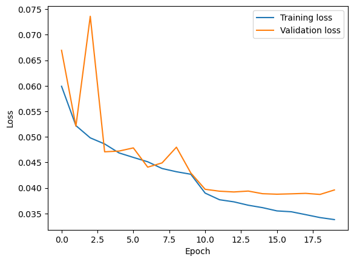

```
'FINISH'
```

```python
plt.plot(train_losses, label='Training loss')
plt.plot(val_losses, label='Validation loss')
plt.xlabel('Epoch')
plt.ylabel('Loss')
plt.legend()
plt.show()
FINISH
```

**Plot the training and validation accuracies**

This plot shows the training and validation accuracies during the training process.

- The x-axis represents the epoch number, which indicates the progress of the training process.
- The y-axis represents the accuracy value, which is the proportion of correct predictions made by the model.
- The blue line (labeled 'Training accuracy') shows the training accuracy at each epoch. It represents how well the model is correctly classifying the training dataset. As the model learns, the training accuracy is expected to increase.
- The orange line (labeled 'Validation accuracy') shows the validation accuracy at each epoch. It represents how well the model generalizes to new, unseen data. The validation accuracy is used to monitor the model's performance on a held-out dataset and to prevent overfitting.
- Ideally, both training and validation accuracies should increase over time, and the validation accuracy should closely follow the training accuracy. If the validation accuracy starts decreasing while the training accuracy continues to increase, it might indicate that the model is overfitting to the training dataset.

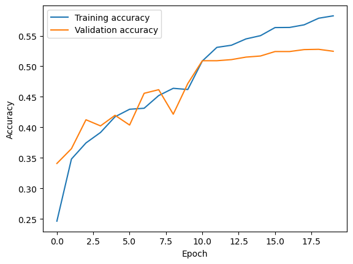

```
'FINISH'
```

```python
plt.plot(train_accuracies, label='Training accuracy')
plt.plot(val_accuracies, label='Validation accuracy')
plt.xlabel('Epoch')
plt.ylabel('Accuracy')
plt.legend()
plt.show()
FINISH
```

**Plot confusion matrix**

This code snippet generates a confusion matrix plot for the model's predictions on the test dataset.

1. Set the model to evaluation mode using `model.eval()`.
2. Initialize empty lists `y_pred` and `y_true` to store the predicted and true labels, respectively.
3. Loop through the batches of images and labels in the test data loader:
   - Move the inputs and labels to the computation device (GPU or CPU).
   - Pass the inputs through the model to get the outputs.
   - Get the predicted class by finding the index with the maximum value in the outputs (using `torch.max()`).
   - Extend `y_pred` and `y_true` lists with the predicted and true labels, respectively, after converting them to NumPy arrays and moving them back to the CPU.
4. Compute the confusion matrix using the `confusion_matrix()` function from scikit-learn, with `y_true` and `y_pred` as inputs.
5. Define the `labels` variable as the list of emotions.
6. Create a heatmap plot using the Seaborn library:
   - Initialize a figure with a defined size (8x8 inches).
   - Use `sns.heatmap()` with the confusion matrix, annotations, color map ('Blues'), format for annotations ('g'), x-axis tick labels, y-axis tick labels, and axes object.
   - Set the x-axis label to 'Predicted Labels'.
   - Set the y-axis label to 'True Labels'.
7. Display the plot using `plt.show()`.

The resulting confusion matrix plot shows the performance of the model in terms of how it classified the test dataset. Each row represents the true labels, and each column represents the predicted labels. The diagonal elements represent the number of instances where the predicted label matches the true label. Off-diagonal elements indicate misclassifications. The confusion matrix helps identify which classes the model has difficulties classifying correctly and if there are any systematic errors in the predictions.

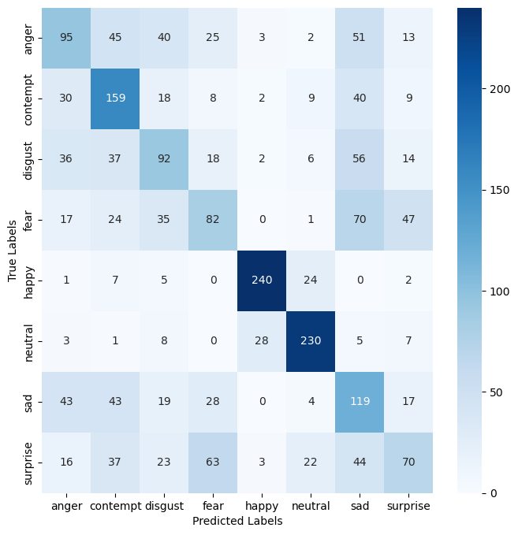

```
'FINISH'
```

```python
model.eval()
y_pred = []
y_true = []

with torch.no_grad():
    for inputs, labels in test_loader:
        inputs, labels = inputs.to(device), labels.to(device)
        outputs = model(inputs)
        _, predicted = torch.max(outputs.data, 1)
        y_pred.extend(predicted.cpu().numpy())
        y_true.extend(labels.cpu().numpy())

cm = confusion_matrix(y_true, y_pred)
labels = emotions

fig, ax = plt.subplots(figsize=(8, 8))
sns.heatmap(cm, annot=True, cmap='Blues', fmt='g', xticklabels=labels, yticklabels=labels, ax=ax)
plt.xlabel('Predicted Labels')
plt.ylabel('True Labels')
plt.show()
FINISH
```

**Visualize some example predictions**

1. Define the `visualize_predictions()` function with the following parameters:
   - `model`: the trained model
   - `device`: the computation device (GPU or CPU)
   - `loader`: the data loader for the test dataset
   - `class_names`: a list of class names (emotions)
2. Set the model to evaluation mode using `model.eval()`.
3. Get a batch of images and labels from the data loader using `iter(loader)` and `next()`.
4. Move the images and labels to the computation device (GPU or CPU).
5. Compute the model's predictions for the images:
   - Pass the images through the model to get the outputs.
   - Get the predicted class by finding the index with the maximum value in the outputs (using `torch.max()`).
6. Move the images and predicted labels back to the CPU.
7. Create a list of predicted label names and a list of true label names.
8. Initialize a figure with a 2x5 grid of subplots and a defined size (10x5 inches).
9. Loop through the subplots, display the images along with their true and predicted labels:
   - If the image is grayscale, display it using the 'gray' color map.
   - If the image is RGB, display it by permuting the image tensor and squeezing the dimensions.
   - Set the title of each subplot to include the true and predicted label names.
   - Remove the axis from each subplot.
10. Display the figure using `plt.show()`.

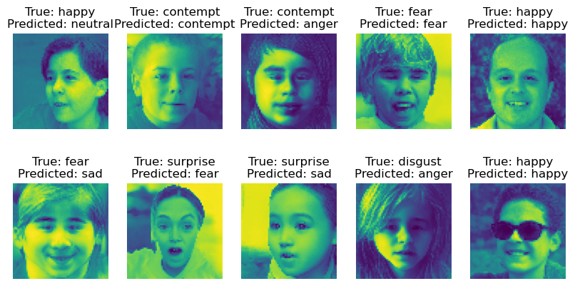

```
'FINISH'
```

```python
images, labels = next(iter(test_loader))

def visualize_predictions(model, device, loader, class_names):
    model.eval()
    dataiter = iter(loader)
    images, labels = dataiter.next()
    images, labels = images.to(device), labels.to(device)
    with torch.no_grad():
        outputs = model(images)
        _, predicted = torch.max(outputs, 1)

    images = images.cpu()
    predicted = predicted.cpu()

    predicted_text = [class_names[predicted[i]] for i in range(len(predicted))]
    labels_text = [class_names[labels[i]] for i in range(len(labels))]

    fig, axs = plt.subplots(2, 5, figsize=(10, 5))
    for i, ax in enumerate(axs.flat):
        if images[i].dim() == 2:
            ax.imshow(images[i], cmap='gray')
        else:
            ax.imshow(images[i].permute(1, 2, 0).squeeze())
        ax.set_title(f'True: {labels_text[i]}\nPredicted: {predicted_text[i]}')
        ax.axis('off')

    plt.show()

with torch.no_grad():
    outputs = model(images.to(device))
    _, predicted = torch.max(outputs.data, 1)

labels_text = [emotions[label] for label in labels]
predicted_text = [emotions[label] for label in predicted.cpu().numpy()]

fig, axs = plt.subplots(2, 5, figsize=(10, 5))
for i, ax in enumerate(axs.flat):
    if images[i].dim() == 2:
        ax.imshow(images[i], cmap='gray')
    else:
        ax.imshow(images[i].permute(1, 2, 0).squeeze())
    ax.set_title(f'True: {labels_text[i]}\nPredicted: {predicted_text[i]}')
    ax.axis('off')
plt.show()

FINISH
```

**Model summary**

The output of the `summary()` function will show the model's layers, their output shapes, and the number of parameters. This information is useful for understanding the model's architecture and its complexity, as well as for debugging purposes.

Explanation of the key information provided in the result:

1. Layer (type): This column shows the type of layer used in the network, such as Conv2d (2D convolutional layer), BatchNorm2d (2D batch normalization layer), ReLU (rectified linear unit activation function), and so on.
2. Output Shape: This column displays the shape of the output tensor after passing through each layer. The `-1` in the first dimension represents the batch size, which can be any positive integer.
3. Param #: This column shows the number of trainable parameters for each layer. The total number of trainable parameters in the network is shown at the end of the summary.

Additional information provided at the end of the summary includes:

- Total params: The total number of parameters in the model (11,174,344 in this case).
- Trainable params: The number of parameters that will be updated during training (11,174,344 in this case).
- Non-trainable params: The number of parameters that will not be updated during training (0 in this case).
- Input size (MB): The memory size of the input tensor (0.02 MB in this case).
- Forward/backward pass size (MB): The memory size required to store intermediate values during forward and backward passes (5.13 MB in this case).
- Params size (MB): The memory size of the model's parameters (42.63 MB in this case).
- Estimated Total Size (MB): The estimated total memory size required by the model (47.77 MB in this case).

```python
summary(model.to(device), input_size=(1, 64, 64))
```

```
----------------------------------------------------------------
        Layer (type)               Output Shape         Param #
================================================================
            Conv2d-1           [-1, 64, 32, 32]           3,136
       BatchNorm2d-2           [-1, 64, 32, 32]             128
              ReLU-3           [-1, 64, 32, 32]               0
         MaxPool2d-4           [-1, 64, 16, 16]               0
            Conv2d-5           [-1, 64, 16, 16]          36,864
       BatchNorm2d-6           [-1, 64, 16, 16]             128
              ReLU-7           [-1, 64, 16, 16]               0
            Conv2d-8           [-1, 64, 16, 16]          36,864
       BatchNorm2d-9           [-1, 64, 16, 16]             128
             ReLU-10           [-1, 64, 16, 16]               0
       BasicBlock-11           [-1, 64, 16, 16]               0
           Conv2d-12           [-1, 64, 16, 16]          36,864
      BatchNorm2d-13           [-1, 64, 16, 16]             128
             ReLU-14           [-1, 64, 16, 16]               0
           Conv2d-15           [-1, 64, 16, 16]          36,864
      BatchNorm2d-16           [-1, 64, 16, 16]             128
             ReLU-17           [-1, 64, 16, 16]               0
       BasicBlock-18           [-1, 64, 16, 16]               0
           Conv2d-19            [-1, 128, 8, 8]          73,728
      BatchNorm2d-20            [-1, 128, 8, 8]             256
             ReLU-21            [-1, 128, 8, 8]               0
           Conv2d-22            [-1, 128, 8, 8]         147,456
      BatchNorm2d-23            [-1, 128, 8, 8]             256
           Conv2d-24            [-1, 128, 8, 8]           8,192
      BatchNorm2d-25            [-1, 128, 8, 8]             256
             ReLU-26            [-1, 128, 8, 8]               0
       BasicBlock-27            [-1, 128, 8, 8]               0
           Conv2d-28            [-1, 128, 8, 8]         147,456
      BatchNorm2d-29            [-1, 128, 8, 8]             256
             ReLU-30            [-1, 128, 8, 8]               0
           Conv2d-31            [-1, 128, 8, 8]         147,456
      BatchNorm2d-32            [-1, 128, 8, 8]             256
             ReLU-33            [-1, 128, 8, 8]               0
       BasicBlock-34            [-1, 128, 8, 8]               0
           Conv2d-35            [-1, 256, 4, 4]         294,912
      BatchNorm2d-36            [-1, 256, 4, 4]             512
             ReLU-37            [-1, 256, 4, 4]               0
```

[output cut: 26 more lines]

```
      BatchNorm2d-64            [-1, 512, 2, 2]           1,024
             ReLU-65            [-1, 512, 2, 2]               0
       BasicBlock-66            [-1, 512, 2, 2]               0
AdaptiveAvgPool2d-67            [-1, 512, 1, 1]               0
           Linear-68                    [-1, 8]           4,104
================================================================
Total params: 11,174,344
Trainable params: 11,174,344
Non-trainable params: 0
----------------------------------------------------------------
Input size (MB): 0.02
Forward/backward pass size (MB): 5.13
Params size (MB): 42.63
Estimated Total Size (MB): 47.77
----------------------------------------------------------------
```

**ResNet18 VS Simple MLP**

```
Skipping non-image file: data/AffectNet/anger/.ipynb_checkpoints
Skipping non-image file: data/AffectNet/contempt/.ipynb_checkpoints
Epoch [1/20] - Loss (Train): 0.0641, Loss (Val): 0.0633, Acc (Train): 0.1884, Acc (Val): 0.2249
Epoch [2/20] - Loss (Train): 0.0621, Loss (Val): 0.0617, Acc (Train): 0.2631, Acc (Val): 0.3011
Epoch [3/20] - Loss (Train): 0.0611, Loss (Val): 0.0612, Acc (Train): 0.3007, Acc (Val): 0.3070
Epoch [4/20] - Loss (Train): 0.0607, Loss (Val): 0.0618, Acc (Train): 0.3185, Acc (Val): 0.2933
Epoch [5/20] - Loss (Train): 0.0598, Loss (Val): 0.0601, Acc (Train): 0.3497, Acc (Val): 0.3463
Epoch [6/20] - Loss (Train): 0.0596, Loss (Val): 0.0605, Acc (Train): 0.3512, Acc (Val): 0.3307
Epoch [7/20] - Loss (Train): 0.0594, Loss (Val): 0.0598, Acc (Train): 0.3580, Acc (Val): 0.3508
Epoch [8/20] - Loss (Train): 0.0590, Loss (Val): 0.0593, Acc (Train): 0.3748, Acc (Val): 0.3677
Epoch [9/20] - Loss (Train): 0.0588, Loss (Val): 0.0606, Acc (Train): 0.3806, Acc (Val): 0.3266
Epoch [10/20] - Loss (Train): 0.0586, Loss (Val): 0.0588, Acc (Train): 0.3862, Acc (Val): 0.3887
Epoch [11/20] - Loss (Train): 0.0583, Loss (Val): 0.0590, Acc (Train): 0.3964, Acc (Val): 0.3923
Epoch [12/20] - Loss (Train): 0.0582, Loss (Val): 0.0595, Acc (Train): 0.3946, Acc (Val): 0.3631
Epoch [13/20] - Loss (Train): 0.0580, Loss (Val): 0.0581, Acc (Train): 0.4055, Acc (Val): 0.4197
Epoch [14/20] - Loss (Train): 0.0580, Loss (Val): 0.0582, Acc (Train): 0.4048, Acc (Val): 0.4083
Epoch [15/20] - Loss (Train): 0.0579, Loss (Val): 0.0581, Acc (Train): 0.4140, Acc (Val): 0.4174
Epoch [16/20] - Loss (Train): 0.0576, Loss (Val): 0.0587, Acc (Train): 0.4242, Acc (Val): 0.3882
Epoch [17/20] - Loss (Train): 0.0579, Loss (Val): 0.0595, Acc (Train): 0.4108, Acc (Val): 0.3695
Epoch [18/20] - Loss (Train): 0.0576, Loss (Val): 0.0587, Acc (Train): 0.4205, Acc (Val): 0.3937
Epoch [19/20] - Loss (Train): 0.0574, Loss (Val): 0.0589, Acc (Train): 0.4288, Acc (Val): 0.3882
Epoch [20/20] - Loss (Train): 0.0572, Loss (Val): 0.0582, Acc (Train): 0.4391, Acc (Val): 0.4120
Loss (Test): 1.8701
Accuracy (Test): 0.3899
Elapsed time: 222.06 seconds
Elapsed time: 3.70 minutes
```

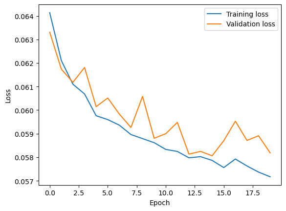

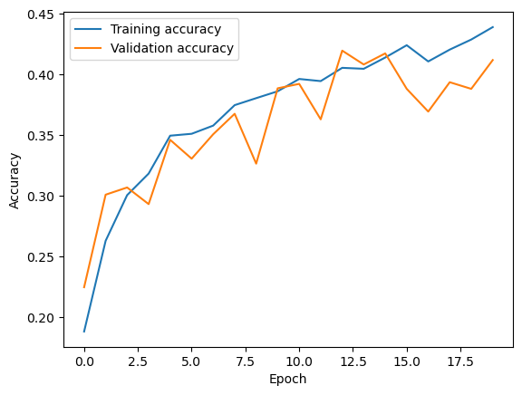

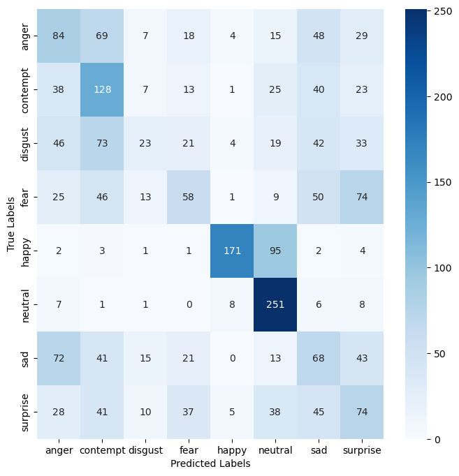

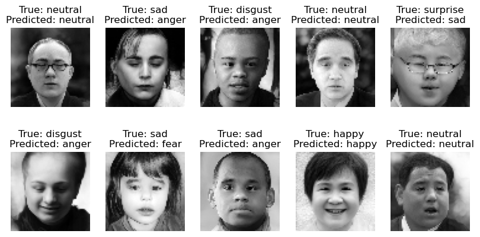

```
----------------------------------------------------------------
        Layer (type)               Output Shape         Param #
================================================================
            Linear-1                  [-1, 128]         524,416
            Linear-2                   [-1, 64]           8,256
            Linear-3                    [-1, 8]             520
================================================================
Total params: 533,192
Trainable params: 533,192
Non-trainable params: 0
----------------------------------------------------------------
Input size (MB): 0.02
Forward/backward pass size (MB): 0.00
Params size (MB): 2.03
Estimated Total Size (MB): 2.05
----------------------------------------------------------------
```

```python
start_time = time.time()

data_dir = 'data/AffectNet'
emotions = ['anger', 'contempt', 'disgust',
            'fear', 'happy', 'neutral', 'sad', 'surprise']
batch_size = 32

filepaths = []
labels = []

for label, emotion in enumerate(emotions):
    emotion_dir = os.path.join(data_dir, emotion)
    for filename in os.listdir(emotion_dir):
        filepaths.append(os.path.join(emotion_dir, filename))
        labels.append(label)

X_temp, X_test, y_temp, y_test = train_test_split(
    filepaths, labels, test_size=0.15, stratify=labels, random_state=42)
X_train, X_val, y_train, y_val = train_test_split(
    X_temp, y_temp, test_size=0.176, stratify=y_temp, random_state=42)

def preprocess_image(filepath, target_size=(64, 64)):
    if not filepath.lower().endswith(('.png', '.jpg', '.jpeg', '.tiff', '.bmp', '.gif')):
        print(f'Skipping non-image file: {filepath}')
        return None

    img = cv2.imread(filepath, cv2.IMREAD_GRAYSCALE)

    if img is None:
        print(f'Error reading file: {filepath}')
        return None

    img = cv2.resize(img, target_size)
    img = img / 255.0
    return img

train_data = []
for filepath, label in zip(X_train, y_train):
    img = preprocess_image(filepath)
    if img is not None:
        train_data.append((img, label))

X_train, y_train = zip(*train_data)
X_train = np.array(X_train)

val_data = []
for filepath, label in zip(X_val, y_val):
    img = preprocess_image(filepath)
    if img is not None:
        val_data.append((img, label))

X_val, y_val = zip(*val_data)
X_val = np.array(X_val)


test_data = []
for filepath, label in zip(X_test, y_test):
    img = preprocess_image(filepath)
    if img is not None:
        test_data.append((img, label))

X_test, y_test = zip(*test_data)
X_test = np.array(X_test)

X_train_torch = torch.tensor(X_train, dtype=torch.float32)
y_train_torch = torch.tensor(y_train, dtype=torch.long)
X_val_torch = torch.tensor(X_val, dtype=torch.float32)
y_val_torch = torch.tensor(y_val, dtype=torch.long)
X_test_torch = torch.tensor(X_test, dtype=torch.float32)
y_test_torch = torch.tensor(y_test, dtype=torch.long)

train_dataset = TensorDataset(X_train_torch, y_train_torch)
val_dataset = TensorDataset(X_val_torch, y_val_torch)
test_dataset = TensorDataset(X_test_torch, y_test_torch)

train_loader = DataLoader(train_dataset, batch_size=batch_size, shuffle=True)
val_loader = DataLoader(val_dataset, batch_size=batch_size, shuffle=True)
test_loader = DataLoader(test_dataset, batch_size=batch_size, shuffle=True)

device = torch.device("cuda:0" if torch.cuda.is_available() else "cpu")

input_size = 64 * 64
hidden1_size = 128
hidden2_size = 64
output_size = len(emotions)


class MLP(nn.Module):
    def __init__(self, input_size, hidden1_size, hidden2_size, output_size):
        super(MLP, self).__init__()
        self.fc1 = nn.Linear(input_size, hidden1_size)
        self.fc2 = nn.Linear(hidden1_size, hidden2_size)
        self.fc3 = nn.Linear(hidden2_size, output_size)

    def forward(self, x):
        x = x.view(x.size(0), -1)
        x = torch.relu(self.fc1(x))
        x = torch.relu(self.fc2(x))
        x = torch.softmax(self.fc3(x), dim=1)
        return x

model = MLP(input_size, hidden1_size, hidden2_size, output_size)
model.to(device)

def calculate_accuracy(y_pred, y_true):
    y_pred = torch.argmax(y_pred, dim=1)
    correct = (y_pred == y_true).sum().item()
    return correct / len(y_true)

model = MLP(input_size, hidden1_size, hidden2_size, output_size)
criterion = nn.CrossEntropyLoss()
optimizer = optim.Adam(model.parameters(), lr=0.001)

num_epochs = 20

train_losses = []
train_accuracies = []
val_losses = []
val_accuracies = []

for epoch in range(num_epochs):
    model.train()
    running_loss = 0.0
    running_corrects = 0
    for inputs, labels in train_loader:
        inputs = inputs.to(device)
        labels = labels.to(device)
        model.to(device)

        optimizer.zero_grad()

        outputs = model(inputs)
        loss = criterion(outputs, labels)
        loss.backward()
        optimizer.step()

        running_loss += loss.item()
        running_corrects += calculate_accuracy(outputs,
                                               labels) * inputs.size(0)

    train_loss = running_loss / len(train_dataset)
    train_accuracy = running_corrects / len(train_dataset)
    train_losses.append(train_loss)
    train_accuracies.append(train_accuracy)

    model.eval()
    running_loss = 0.0
    running_corrects = 0
    with torch.no_grad():
        for inputs, labels in val_loader:
            inputs = inputs.to(device)
            labels = labels.to(device)
            model.to(device)

            outputs = model(inputs)
            loss = criterion(outputs, labels)
            running_loss += loss.item()
            running_corrects += calculate_accuracy(
                outputs,labels) * inputs.size(0)

    val_loss = running_loss / len(val_dataset)
    val_accuracy = running_corrects / len(val_dataset)
    val_losses.append(val_loss)
    val_accuracies.append(val_accuracy)

    print(f'Epoch [{epoch+1}/{num_epochs}] - Loss (Train): {train_loss:.4f}, Loss (Val): {val_loss:.4f}, Acc (Train): {train_accuracy:.4f}, Acc (Val): {val_accuracy:.4f}')

model.eval()
test_running_loss = 0.0
num_batches = 0
for inputs, targets in test_loader:
    inputs, targets = inputs.to(device), targets.to(device)

    outputs = model(inputs)
    loss = criterion(outputs, targets)
    test_running_loss += loss.item()
    num_batches += 1

test_loss = test_running_loss / num_batches

test_running_corrects = 0
for inputs, labels in test_loader:
    inputs, labels = inputs.to(device), labels.to(device)

    outputs = model(inputs)
    test_running_corrects += calculate_accuracy(outputs,
                                                labels) * inputs.size(0)

test_accuracy = test_running_corrects / len(test_dataset)

print(f'Loss (Test): {test_loss:.4f}')
print(f'Accuracy (Test): {test_accuracy:.4f}')

end_time = time.time()
elapsed_time = end_time - start_time
elapsed_time_minutes = elapsed_time / 60.0
print(f"Elapsed time: {elapsed_time:.2f} seconds")
print(f"Elapsed time: {elapsed_time_minutes:.2f} minutes")

plt.plot(train_losses, label='Training loss')
plt.plot(val_losses, label='Validation loss')
plt.xlabel('Epoch')
plt.ylabel('Loss')
plt.legend()
plt.show()

plt.plot(train_accuracies, label='Training accuracy')
plt.plot(val_accuracies, label='Validation accuracy')
plt.xlabel('Epoch')
plt.ylabel('Accuracy')
plt.legend()
plt.show()

model.eval()
y_pred = []
y_true = []

with torch.no_grad():
    for inputs, labels in test_loader:
        inputs, labels = inputs.to(device), labels.to(device)
        outputs = model(inputs)
        _, predicted = torch.max(outputs.data, 1)
        y_pred.extend(predicted.cpu().numpy())
        y_true.extend(labels.cpu().numpy())

cm = confusion_matrix(y_true, y_pred)
labels = emotions

fig, ax = plt.subplots(figsize=(8, 8))
sns.heatmap(cm, annot=True, cmap='Blues', fmt='g', xticklabels=labels, yticklabels=labels, ax=ax)
plt.xlabel('Predicted Labels')
plt.ylabel('True Labels')
plt.show()

images, labels = next(iter(test_loader))

def visualize_predictions(model, device, loader, class_names):
    model.eval()
    dataiter = iter(loader)
    images, labels = dataiter.next()
    images, labels = images.to(device), labels.to(device)
    with torch.no_grad():
        outputs = model(images)
        _, predicted = torch.max(outputs, 1)

    images = images.cpu()
    predicted = predicted.cpu()

    predicted_text = [class_names[predicted[i]] for i in range(len(predicted))]
    labels_text = [class_names[labels[i]] for i in range(len(labels))]

    fig, axs = plt.subplots(2, 5, figsize=(10, 5))
    for i, ax in enumerate(axs.flat):
        if images[i].dim() == 2:
            ax.imshow(images[i], cmap='gray')
        else:
            ax.imshow(images[i].permute(1, 2, 0).squeeze())
        ax.set_title(f'True: {labels_text[i]}\nPredicted: {predicted_text[i]}')
        ax.axis('off')

    plt.show()

with torch.no_grad():
    outputs = model(images.to(device))
    _, predicted = torch.max(outputs.data, 1)

labels_text = [emotions[label] for label in labels]
predicted_text = [emotions[label] for label in predicted.cpu().numpy()]

fig, axs = plt.subplots(2, 5, figsize=(10, 5))
for i, ax in enumerate(axs.flat):
    if images[i].dim() == 2:
        ax.imshow(images[i], cmap='gray')
    else:
        ax.imshow(images[i].permute(1, 2, 0).squeeze())
    ax.set_title(f'True: {labels_text[i]}\nPredicted: {predicted_text[i]}')
    ax.axis('off')
plt.show()

summary(model.to(device), input_size=(1, 64, 64))
```

**ResNet18 VS CNN**

```
Skipping non-image file: data/AffectNet/anger/.ipynb_checkpoints
Skipping non-image file: data/AffectNet/contempt/.ipynb_checkpoints
Skipping non-image file: data/AffectNet/anger/.ipynb_checkpoints
Skipping non-image file: data/AffectNet/contempt/.ipynb_checkpoints
Epoch [1/20] - Loss (Train): 0.0629, Loss (Val): 0.0560, Acc (Train): 0.1696, Acc (Val): 0.2769
Epoch [2/20] - Loss (Train): 0.0539, Loss (Val): 0.0523, Acc (Train): 0.2933, Acc (Val): 0.3239
Epoch [3/20] - Loss (Train): 0.0510, Loss (Val): 0.0501, Acc (Train): 0.3392, Acc (Val): 0.3714
Epoch [4/20] - Loss (Train): 0.0491, Loss (Val): 0.0486, Acc (Train): 0.3756, Acc (Val): 0.3942
Epoch [5/20] - Loss (Train): 0.0476, Loss (Val): 0.0477, Acc (Train): 0.4005, Acc (Val): 0.3978
Epoch [6/20] - Loss (Train): 0.0465, Loss (Val): 0.0462, Acc (Train): 0.4143, Acc (Val): 0.4325
Epoch [7/20] - Loss (Train): 0.0458, Loss (Val): 0.0453, Acc (Train): 0.4276, Acc (Val): 0.4357
Epoch [8/20] - Loss (Train): 0.0452, Loss (Val): 0.0451, Acc (Train): 0.4316, Acc (Val): 0.4439
Epoch [9/20] - Loss (Train): 0.0444, Loss (Val): 0.0459, Acc (Train): 0.4420, Acc (Val): 0.4297
Epoch [10/20] - Loss (Train): 0.0440, Loss (Val): 0.0449, Acc (Train): 0.4514, Acc (Val): 0.4466
Epoch [11/20] - Loss (Train): 0.0423, Loss (Val): 0.0432, Acc (Train): 0.4684, Acc (Val): 0.4699
Epoch [12/20] - Loss (Train): 0.0420, Loss (Val): 0.0432, Acc (Train): 0.4711, Acc (Val): 0.4722
Epoch [13/20] - Loss (Train): 0.0417, Loss (Val): 0.0431, Acc (Train): 0.4818, Acc (Val): 0.4603
Epoch [14/20] - Loss (Train): 0.0417, Loss (Val): 0.0428, Acc (Train): 0.4829, Acc (Val): 0.4681
Epoch [15/20] - Loss (Train): 0.0412, Loss (Val): 0.0429, Acc (Train): 0.4819, Acc (Val): 0.4731
Epoch [16/20] - Loss (Train): 0.0412, Loss (Val): 0.0430, Acc (Train): 0.4834, Acc (Val): 0.4703
Epoch [17/20] - Loss (Train): 0.0412, Loss (Val): 0.0426, Acc (Train): 0.4845, Acc (Val): 0.4786
Epoch [18/20] - Loss (Train): 0.0409, Loss (Val): 0.0428, Acc (Train): 0.4881, Acc (Val): 0.4758
Epoch [19/20] - Loss (Train): 0.0409, Loss (Val): 0.0424, Acc (Train): 0.4906, Acc (Val): 0.4813
Epoch [20/20] - Loss (Train): 0.0408, Loss (Val): 0.0427, Acc (Train): 0.4867, Acc (Val): 0.4786
Loss (Test): 1.3893
Accuracy (Test): 0.4545
Elapsed time: 1367.12 seconds
Elapsed time: 22.79 minutes
```

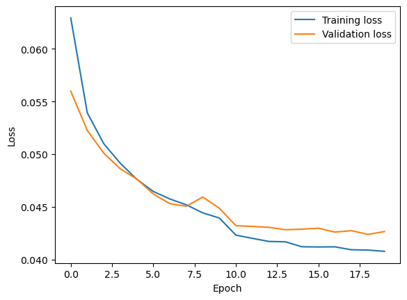

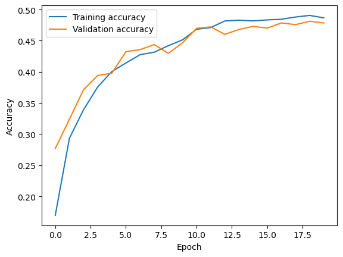

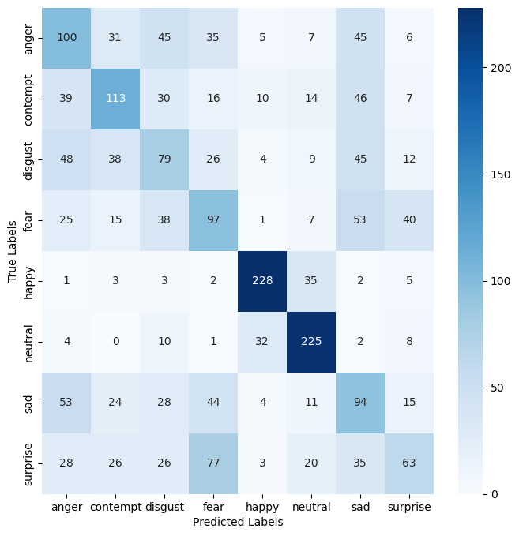

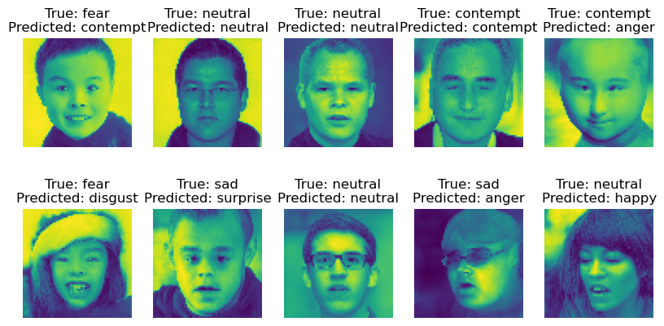

```
----------------------------------------------------------------
        Layer (type)               Output Shape         Param #
================================================================
            Conv2d-1           [-1, 16, 64, 64]             160
         MaxPool2d-2           [-1, 16, 32, 32]               0
            Conv2d-3           [-1, 32, 32, 32]           4,640
         MaxPool2d-4           [-1, 32, 16, 16]               0
            Conv2d-5           [-1, 64, 16, 16]          18,496
         MaxPool2d-6             [-1, 64, 8, 8]               0
            Conv2d-7            [-1, 128, 8, 8]          73,856
         MaxPool2d-8            [-1, 128, 4, 4]               0
            Linear-9                  [-1, 512]       1,049,088
           Linear-10                    [-1, 8]           4,104
================================================================
Total params: 1,150,344
Trainable params: 1,150,344
Non-trainable params: 0
----------------------------------------------------------------
Input size (MB): 0.02
Forward/backward pass size (MB): 1.18
Params size (MB): 4.39
Estimated Total Size (MB): 5.58
----------------------------------------------------------------
```

```python
start_time = time.time()

data_dir = 'data/AffectNet'
emotions = ['anger', 'contempt', 'disgust',
            'fear', 'happy', 'neutral', 'sad', 'surprise']
batch_size = 32
num_epochs = 20
learning_rate = 0.001

filepaths = []
labels = []

for label, emotion in enumerate(emotions):
    emotion_dir = os.path.join(data_dir, emotion)
    for filename in os.listdir(emotion_dir):
        filepaths.append(os.path.join(emotion_dir, filename))
        labels.append(label)

X_temp, X_test, y_temp, y_test = train_test_split(
    filepaths, labels, test_size=0.15, stratify=labels, random_state=42)
X_train, X_val, y_train, y_val = train_test_split(
    X_temp, y_temp, test_size=0.176, stratify=y_temp, random_state=42)


def preprocess_image(filepath, target_size=(64, 64)):
    if not filepath.lower().endswith(('.png', '.jpg', '.jpeg', '.tiff', '.bmp', '.gif')):
        print(f'Skipping non-image file: {filepath}')
        return None

    img = cv2.imread(filepath, cv2.IMREAD_GRAYSCALE)

    if img is None:
        print(f'Error reading file: {filepath}')
        return None

    img = cv2.resize(img, target_size)
    img = Image.fromarray(img)
    return img

train_data = []
for filepath, label in zip(X_train, y_train):
    img = preprocess_image(filepath)
    if img is not None:
        train_data.append((img, label))

val_data = []
for filepath, label in zip(X_val, y_val):
    img = preprocess_image(filepath)
    if img is not None:
        val_data.append((img, label))

test_data = []
for filepath, label in zip(X_test, y_test):
    img = preprocess_image(filepath)
    if img is not None:
        test_data.append((img, label))

class EmotionDataset(Dataset):
    def __init__(self, filepaths, labels, transform=None):
        self.valid_filepaths = []
        self.valid_labels = []
        for filepath, label in zip(filepaths, labels):
            img = preprocess_image(filepath)
            if img is not None:
                self.valid_filepaths.append(filepath)
                self.valid_labels.append(label)
        self.transform = transform

    def __len__(self):
        return len(self.valid_filepaths)

    def __getitem__(self, idx):
        img = preprocess_image(self.valid_filepaths[idx])
        label = self.valid_labels[idx]
        if self.transform:
            img = self.transform(img)
        return img, label

transform_train = transforms.Compose([
    transforms.RandomHorizontalFlip(),
    transforms.RandomRotation(20),
    transforms.ToTensor(),
])

transform_test = transforms.Compose([
    transforms.ToTensor(),
])

train_dataset = EmotionDataset(X_train, y_train, transform=transform_train)
val_dataset = EmotionDataset(X_val, y_val, transform=transform_test)
test_dataset = EmotionDataset(X_test, y_test, transform=transform_test)

train_loader = DataLoader(train_dataset, batch_size=batch_size, shuffle=True, num_workers=4)
val_loader = DataLoader(val_dataset, batch_size=batch_size, shuffle=True, num_workers=4)
test_loader = DataLoader(test_dataset, batch_size=batch_size, shuffle=True, num_workers=4)

device = torch.device("cuda:0" if torch.cuda.is_available() else "cpu")

class CNN(nn.Module):
    def __init__(self, num_classes=8):
        super(CNN, self).__init__()
        self.conv1 = nn.Conv2d(1, 16, kernel_size=3, padding=1)
        self.conv2 = nn.Conv2d(16, 32, kernel_size=3, padding=1)
        self.conv3 = nn.Conv2d(32, 64, kernel_size=3, padding=1)
        self.conv4 = nn.Conv2d(64, 128, kernel_size=3, padding=1)
        self.pool = nn.MaxPool2d(kernel_size=2, stride=2, padding=0)
        self.fc1 = nn.Linear(128 * 4 * 4, 512)
        self.fc2 = nn.Linear(512, num_classes)

    def forward(self, x):
        x = self.pool(F.relu(self.conv1(x)))
        x = self.pool(F.relu(self.conv2(x)))
        x = self.pool(F.relu(self.conv3(x)))
        x = self.pool(F.relu(self.conv4(x)))
        x = x.view(-1, 128 * 4 * 4)
        x = F.relu(self.fc1(x))
        x = self.fc2(x)
        return x

output_size = len(emotions)
model = CNN(num_classes=output_size)
model.to(device)

criterion = nn.CrossEntropyLoss()
optimizer = optim.Adam(model.parameters(), lr=learning_rate)
scheduler = optim.lr_scheduler.StepLR(optimizer, step_size=10, gamma=0.1)

def calculate_accuracy(y_pred, y_true):
    y_pred = torch.argmax(y_pred, dim=1)
    correct = (y_pred == y_true).sum().item()
    return correct / len(y_true)

train_losses = []
train_accuracies = []
val_losses = []
val_accuracies = []

for epoch in range(num_epochs):
    model.train()
    running_loss = 0.0
    running_corrects = 0
    for inputs, labels in train_loader:
        inputs = inputs.to(device)
        labels = labels.to(device)
        model.to(device)

        optimizer.zero_grad()

        outputs = model(inputs)
        loss = criterion(outputs, labels)
        loss.backward()
        optimizer.step()

        running_loss += loss.item()
        running_corrects += calculate_accuracy(outputs,
                                               labels) * inputs.size(0)

    train_loss = running_loss / len(train_dataset)
    train_accuracy = running_corrects / len(train_dataset)
    train_losses.append(train_loss)
    train_accuracies.append(train_accuracy)

    model.eval()
    running_loss = 0.0
    running_corrects = 0
    with torch.no_grad():
        for inputs, labels in val_loader:
            inputs = inputs.to(device)
            labels = labels.to(device)
            model.to(device)

            outputs = model(inputs)
            loss = criterion(outputs, labels)
            running_loss += loss.item()
            running_corrects += calculate_accuracy(
                outputs,labels) * inputs.size(0)

    val_loss = running_loss / len(val_dataset)
    val_accuracy = running_corrects / len(val_dataset)
    val_losses.append(val_loss)
    val_accuracies.append(val_accuracy)
    scheduler.step()

    print(f'Epoch [{epoch+1}/{num_epochs}] - Loss (Train): {train_loss:.4f}, Loss (Val): {val_loss:.4f}, Acc (Train): {train_accuracy:.4f}, Acc (Val): {val_accuracy:.4f}')

model.eval()
test_running_loss = 0.0
num_batches = 0
for inputs, targets in test_loader:
    inputs, targets = inputs.to(device), targets.to(device)

    outputs = model(inputs)
    loss = criterion(outputs, targets)
    test_running_loss += loss.item()
    num_batches += 1

test_loss = test_running_loss / num_batches

test_running_corrects = 0
for inputs, labels in test_loader:
    inputs, labels = inputs.to(device), labels.to(device)

    outputs = model(inputs)
    test_running_corrects += calculate_accuracy(outputs,
                                                labels) * inputs.size(0)

test_accuracy = test_running_corrects / len(test_dataset)

print(f'Loss (Test): {test_loss:.4f}')
print(f'Accuracy (Test): {test_accuracy:.4f}')

end_time = time.time()
elapsed_time = end_time - start_time
elapsed_time_minutes = elapsed_time / 60.0
print(f"Elapsed time: {elapsed_time:.2f} seconds")
print(f"Elapsed time: {elapsed_time_minutes:.2f} minutes")


plt.plot(train_losses, label='Training loss')
plt.plot(val_losses, label='Validation loss')
plt.xlabel('Epoch')
plt.ylabel('Loss')
plt.legend()
plt.show()

plt.plot(train_accuracies, label='Training accuracy')
plt.plot(val_accuracies, label='Validation accuracy')
plt.xlabel('Epoch')
plt.ylabel('Accuracy')
plt.legend()
plt.show()

model.eval()
y_pred = []
y_true = []

with torch.no_grad():
    for inputs, labels in test_loader:
        inputs, labels = inputs.to(device), labels.to(device)
        outputs = model(inputs)
        _, predicted = torch.max(outputs.data, 1)
        y_pred.extend(predicted.cpu().numpy())
        y_true.extend(labels.cpu().numpy())

cm = confusion_matrix(y_true, y_pred)
labels = emotions

fig, ax = plt.subplots(figsize=(8, 8))
sns.heatmap(cm, annot=True, cmap='Blues', fmt='g', xticklabels=labels, yticklabels=labels, ax=ax)
plt.xlabel('Predicted Labels')
plt.ylabel('True Labels')
plt.show()

images, labels = next(iter(test_loader))

def visualize_predictions(model, device, loader, class_names):
    model.eval()
    dataiter = iter(loader)
    images, labels = dataiter.next()
    images, labels = images.to(device), labels.to(device)
    with torch.no_grad():
        outputs = model(images)
        _, predicted = torch.max(outputs, 1)

    images = images.cpu()
    predicted = predicted.cpu()

    predicted_text = [class_names[predicted[i]] for i in range(len(predicted))]
    labels_text = [class_names[labels[i]] for i in range(len(labels))]

    fig, axs = plt.subplots(2, 5, figsize=(10, 5))
    for i, ax in enumerate(axs.flat):
        if images[i].dim() == 2:
            ax.imshow(images[i], cmap='gray')
        else:
            ax.imshow(images[i].permute(1, 2, 0).squeeze())
        ax.set_title(f'True: {labels_text[i]}\nPredicted: {predicted_text[i]}')
        ax.axis('off')

    plt.show()

with torch.no_grad():
    outputs = model(images.to(device))
    _, predicted = torch.max(outputs.data, 1)

labels_text = [emotions[label] for label in labels]
predicted_text = [emotions[label] for label in predicted.cpu().numpy()]

fig, axs = plt.subplots(2, 5, figsize=(10, 5))
for i, ax in enumerate(axs.flat):
    if images[i].dim() == 2:
        ax.imshow(images[i], cmap='gray')
    else:
        ax.imshow(images[i].permute(1, 2, 0).squeeze())
    ax.set_title(f'True: {labels_text[i]}\nPredicted: {predicted_text[i]}')
    ax.axis('off')
plt.show()

summary(model.to(device), input_size=(1, 64, 64))
```